# Detailed Exploratory Data Analysis UP Elections

Bukun

The election to the 17th Uttar Pradesh Legislative Assembly was held from 11 February to 8 March 2017 in 7 phases. An analysis has been conducted and structured as outlined in the table of contents.

# 1 Acknowledgements

1. Ankit - Creator of the Dataset
2. Drawn inspiration from Manish Kumar’s kernel.

**Stay Tuned** , more updates would be provided. If you like the EDA, please upvote it.

# 2 Parties

|  | Parties |
| --- | --- |
| 1 | INC |
| 2 | BJP+ |
| 3 | BSP |
| 4 | Independent |
| 5 | None of the Above |
| 6 | others |
| 7 | RLD |
| 8 | SP |

# 3 Districts

There are total **75** districts

|  | districts |
| --- | --- |
| 1 | Agra |
| 2 | Aligarh |
| 3 | Allahabad |
| 4 | Ambedkar Nagar |
| 5 | Amethi |
| 6 | Amroha |
| 7 | Auraiya |
| 8 | Azamgarh |
| 9 | Baghpat |
| 10 | Bahraich |

[output cut: 65 more lines]

# 4 Constituencies

There are total **403** constituencies.

|  | Constituencies |
| --- | --- |
| 1 | Agra Cantt. (SC) |
| 2 | Agra North |
| 3 | Agra Rural (SC) |
| 4 | Agra South |
| 5 | Ajagara (SC) |
| 6 | Akbarpur |
| 7 | Akbarpur - raniya |
| 8 | Alapur (SC) |
| 9 | Aliganj |
| 10 | Aligarh |

[output cut: 393 more lines]

# 5 State Analysis

## 5.1 Winning Parties Position

We explore the seats won by each of the parties in this section.

1. **BJP** with 325 seats
2. **SP** with 47 seats
3. **BSP** with 19 seats
4. **INC** with 7 seats

Awesome performance by BJP.

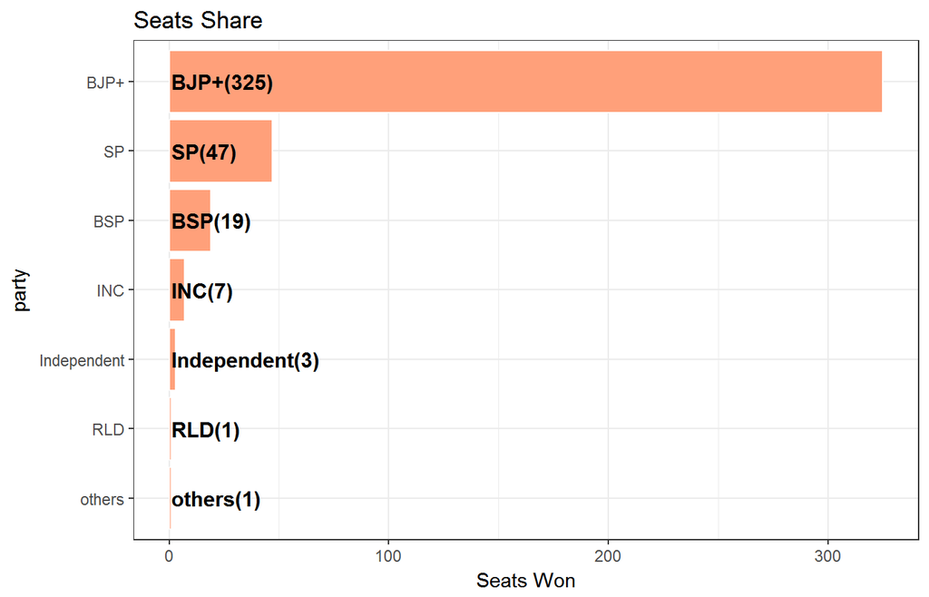

## 5.2 Overall Vote Percentage

Vote Percentage wise, **BJP** beats **SP** by ( 41%-22% ) = 19%

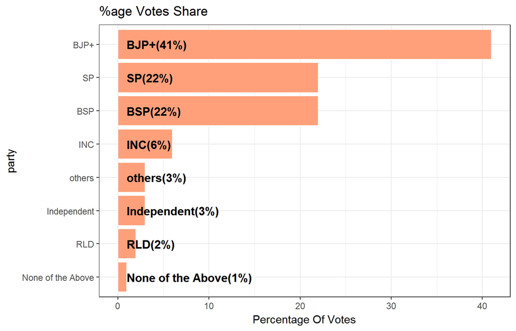

## 5.3 The Winners of 403 Constituencies

|  | seat_allotment | phase | ac_no | ac | district | candidate | party | votes |
| --- | --- | --- | --- | --- | --- | --- | --- | --- |
| 1 | INC | 2 | 1 | Behat | Saharanpur | NARESH SAINI | INC | 97035 |
| 2 | INC | 2 | 2 | Nakur | Saharanpur | DR.DHARAM SINGH SAINI | BJP+ | 94375 |
| 3 | SP | 2 | 3 | Saharanpur Nagar | Saharanpur | SANJAY GARG | SP | 127210 |
| 4 | INC | 2 | 4 | Saharanpur | Saharanpur | MASOOD AKHTAR | INC | 87689 |
| 5 | SP | 2 | 5 | Deoband | Saharanpur | BRIJESH | BJP+ | 102244 |
| 6 | INC | 2 | 6 | Rampur maniharan (SC) | Saharanpur | DEVENDER KUMAR NIM | BJP+ | 76465 |
| 7 | FF | 2 | 7 | Gangoh | Saharanpur | PRADEEP KUMAR | BJP+ | 99446 |
| 8 | SP | 1 | 8 | Kairana | Shamli | NAHID HASAN | SP | 98830 |
| 9 | SP | 1 | 9 | Thana bhawan | Shamli | SURESH KUMAR | BJP+ | 90995 |
| 10 | INC | 1 | 10 | Shamli | Shamli | TEJENDRA NIRWAL | BJP+ | 70085 |

[output cut: 393 more lines]

# 6 Winners Margin Analysis

The below table shows the Winners margin from the highest to the lowest winning margins.

## 6.1 Top 10 highest Winning Margins

|  | phase | ac_no | ac | district | candidate | party | votes | WinningMargin |
| --- | --- | --- | --- | --- | --- | --- | --- | --- |
| 1 | 1 | 55 | Sahibabad | Ghaziabad | SUNIL KUMAR SHARMA | BJP+ | 262741 | 150685 |
| 2 | 4 | 229 | Rath (SC) | Hamirpur | MANISHA ANURAGI | BJP+ | 147526 | 104643 |
| 3 | 1 | 61 | Noida | Gautam Buddha Nagar | PANKAJ SINGH | BJP+ | 162417 | 104016 |
| 4 | 4 | 246 | Kunda | Pratapgarh | RAGHURAJ PRATAP SINGH | Independent | 136597 | 103647 |
| 5 | 1 | 84 | Mathura | Mathura | SHRIKANT SHARMA | BJP+ | 143361 | 101161 |
| 6 | 4 | 227 | Mehroni (SC) | Lalitpur | MANOHAR LAL | BJP+ | 159291 | 99564 |
| 7 | 3 | 217 | Maharajpur | Kanpur Nagar | SATISH MAHANA | BJP+ | 132394 | 91826 |
| 8 | 1 | 54 | Muradnagar | Ghaziabad | AJIT PAL TYAGI | BJP+ | 140759 | 89612 |
| 9 | 4 | 180 | Rae bareli | Raebareli | ADITI SINGH | INC | 128319 | 89163 |
| 10 | 1 | 89 | Agra North | Agra | JAGAN PRASAD GARG | BJP+ | 135120 | 86320 |

## 6.2 Top 10 lowest Winning Margins

|  | phase | ac_no | ac | district | candidate | party | votes | WinningMargin |
| --- | --- | --- | --- | --- | --- | --- | --- | --- |
| 394 | 7 | 392 | Bhadohi | Sant Ravidas Nagar | RAVINDRA NATH TRIPATHI | BJP+ | 79519 | 1105 |
| 395 | 7 | 403 | Duddhi (SC) | Sonbhadra | HAR IRAM | BJP+ | 64399 | 1085 |
| 396 | 6 | 346 | Mubarakpur | Azamgarh | SHAH ALAM URF GUDDU JAMALI | BSP | 70705 | 688 |
| 397 | 2 | 6 | Rampur maniharan (SC) | Saharanpur | DEVENDER KUMAR NIM | BJP+ | 76465 | 595 |
| 398 | 6 | 355 | Muhammadabad- gohna (SC) | Mau | SHRIRAM SONKAR | BJP+ | 73493 | 538 |
| 399 | 3 | 176 | Mohanlalganj (SC) | Lucknow | AMBRISH SINGH PUSHKAR | SP | 71574 | 530 |
| 400 | 5 | 290 | Shrawasti | Shravasti | RAM FERAN | BJP+ | 79437 | 445 |
| 401 | 1 | 82 | Mant | Mathura | SHYAM SUNDER SHARMA | BSP | 65862 | 432 |
| 402 | 1 | 16 | Meerapur | Muzaffarnagar | AVTAR SINGH BHADANA | BJP+ | 69035 | 193 |
| 403 | 5 | 306 | Dumariyaganj | Siddharthnagar | RAGHVENDRA PRATAP SINGH | BJP+ | 67227 | 171 |

# 7 District Seat Analysis

## 7.1 No of constituencies per District

**Allahabad, Azamgarh ,Kanpur Nagar, Agra and Bareilly** are the top 5 districts with the most constituencies.

|  | Districts | No.of.Constituencies |
| --- | --- | --- |
| 1 | Allahabad | 12 |
| 2 | Azamgarh | 10 |
| 3 | Kanpur Nagar | 10 |
| 4 | Agra | 9 |
| 5 | Bareilly | 9 |
| 6 | Gorakhpur | 9 |
| 7 | Jaunpur | 9 |
| 8 | Lucknow | 9 |
| 9 | Sitapur | 9 |
| 10 | Bijnor | 8 |

[output cut: 65 more lines]

## 7.2 Allahabad District Winners Analysis

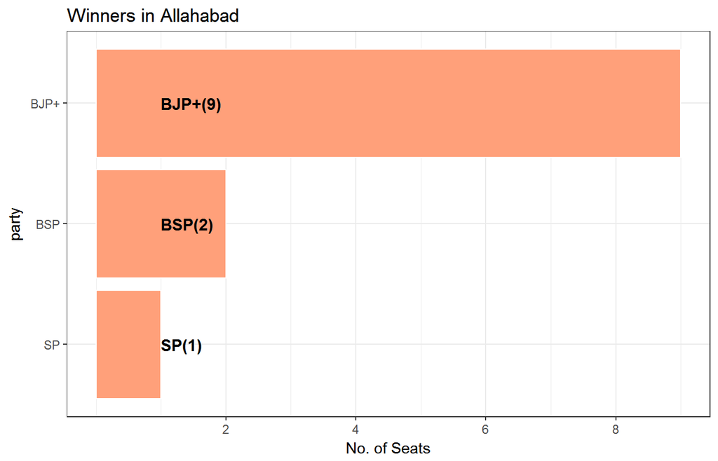

## 7.3 Azamgarh District Winners Analysis

**SP** and **BSP** have both beaten **BJP** in **Azamgarh**

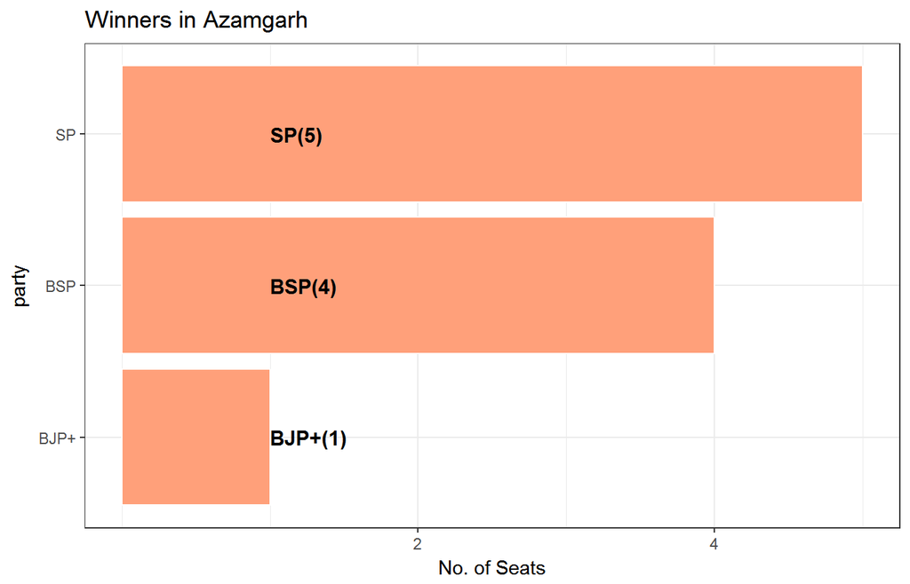

### 7.3.1 Azamgarh District Winners

We dive deep into Azamgarh to investigate how **SP** and **BSP** have both beaten **BJP**

|  | seat_allotment | phase | ac_no | ac | district | candidate | party | votes | WinningMargin |
| --- | --- | --- | --- | --- | --- | --- | --- | --- | --- |
| 1 | SP | 6 | 347 | Azamgarh | Azamgarh | DURGA PRASAD | SP | 88087 | 26262 |
| 2 | SP | 6 | 348 | Nizamabad | Azamgarh | ALAMBADI | SP | 67274 | 18529 |
| 3 | SP | 6 | 344 | Gopalpur | Azamgarh | NAFEES AHMAD | SP | 70980 | 14960 |
| 4 | SP | 6 | 349 | Phoolpur pawai | Azamgarh | ARUN KUMAR YADAV | BJP+ | 68435 | 7295 |
| 5 | SP | 6 | 345 | Sagri | Azamgarh | BANDANA SINGH | BSP | 62203 | 5475 |
| 6 | SP | 6 | 352 | Mehnagar (SC) | Azamgarh | KALPNATH PASWAN | SP | 69037 | 5412 |
| 7 | SP | 6 | 350 | Didarganj | Azamgarh | SUKHDEV RAJBHAR | BSP | 62125 | 3645 |
| 8 | SP | 6 | 343 | Atrauliya | Azamgarh | DR.SANGRAM YADAV | SP | 74276 | 2467 |
| 9 | SP | 6 | 351 | Lalganj (SC) | Azamgarh | AZAD ARI MARDAN | BSP | 72715 | 2227 |
| 10 | SP | 6 | 346 | Mubarakpur | Azamgarh | SHAH ALAM URF GUDDU JAMALI | BSP | 70705 | 688 |

## 7.4 Kanpur Nagar District Winners Analysis

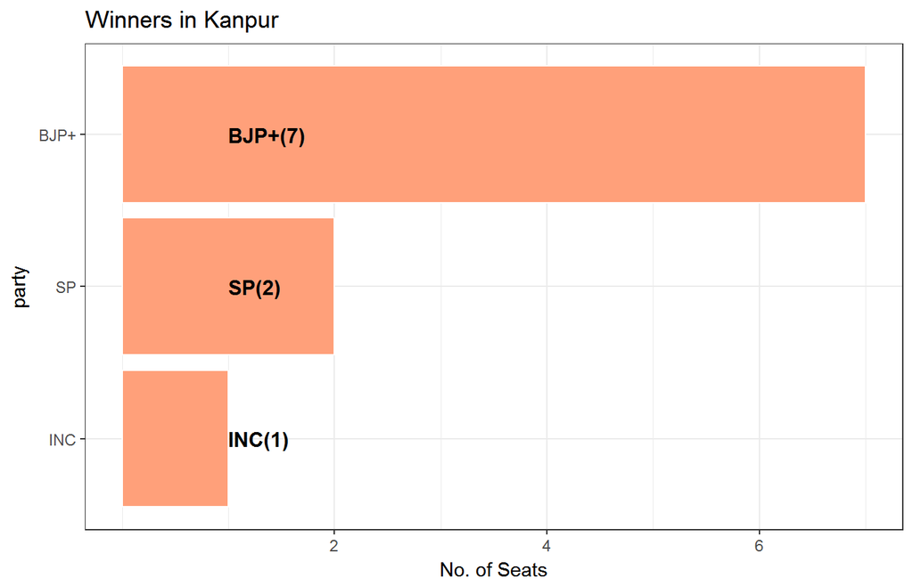

## 7.5 Agra District Winners Analysis

[figure not shown]

## 7.6 Bareilly District Winners Analysis

[figure not shown]

# 8 Phase Analysis

## 8.1 Phase 1 Districts

There are 15 Phase 1 districts.

|  | Phase 1 Districts |
| --- | --- |
| 1 | Agra |
| 2 | Aligarh |
| 3 | Baghpat |
| 4 | Bulandshahr |
| 5 | Etah |
| 6 | Firozabad |
| 7 | Gautam Buddha Nagar |
| 8 | Ghaziabad |
| 9 | Hapur |
| 10 | Hathras |

[output cut: 5 more lines]

## 8.2 Phase 1 Winners

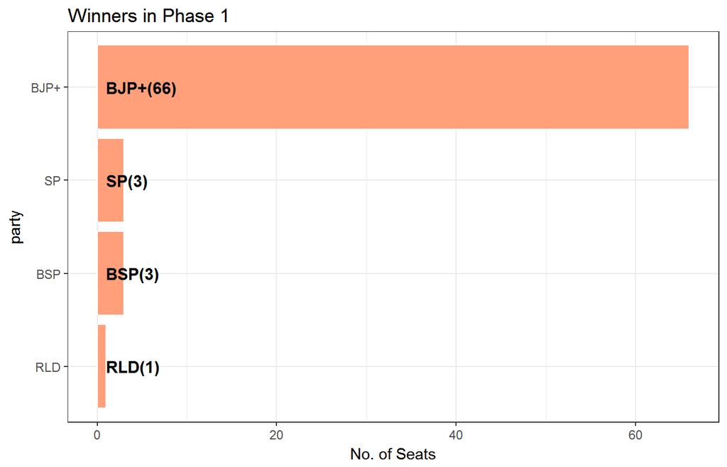

## 8.3 Phase 2 Districts

There are 11 Phase 2 districts.

|  | Phase 2 Districts |
| --- | --- |
| 1 | Amroha |
| 2 | Bareilly |
| 3 | Bijnor |
| 4 | Budaun |
| 5 | Lakhimpur Kheri |
| 6 | Moradabad |
| 7 | Pilibhit |
| 8 | Rampur |
| 9 | Saharanpur |
| 10 | Sambhal |

[output cut: 1 more lines]

## 8.4 Phase 2 Winners

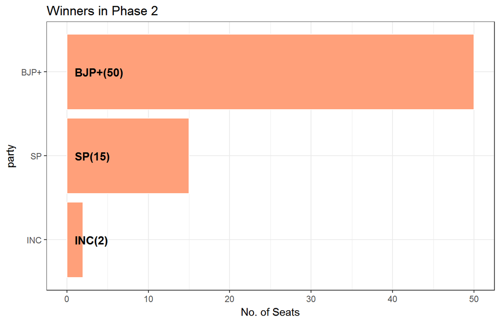

## 8.5 Phase 3 Districts

There are 12 Phase 3 districts.

|  | Phase 3 Districts |
| --- | --- |
| 1 | Auraiya |
| 2 | Barabanki |
| 3 | Etawah |
| 4 | Farrukhabad |
| 5 | Hardoi |
| 6 | Kannauj |
| 7 | Kanpur Dehat |
| 8 | Kanpur Nagar |
| 9 | Lucknow |
| 10 | Mainpuri |

[output cut: 2 more lines]

## 8.6 Phase 3 Winners

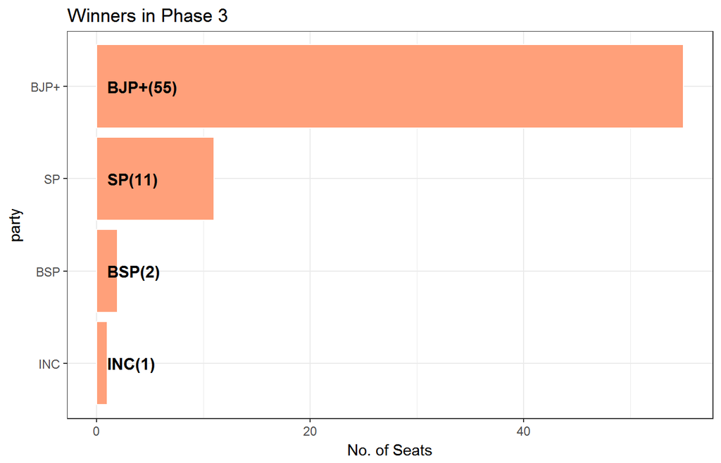

## 8.7 Phase 4 Districts

There are 12 Phase 4 districts.

|  | Phase 4 Districts |
| --- | --- |
| 1 | Allahabad |
| 2 | Banda |
| 3 | Chitrakoot |
| 4 | Fatehpur |
| 5 | Hamirpur |
| 6 | Jalaun |
| 7 | Jhansi |
| 8 | Kaushambi |
| 9 | Lalitpur |
| 10 | Mahoba |

[output cut: 2 more lines]

## 8.8 Phase 4 Winners

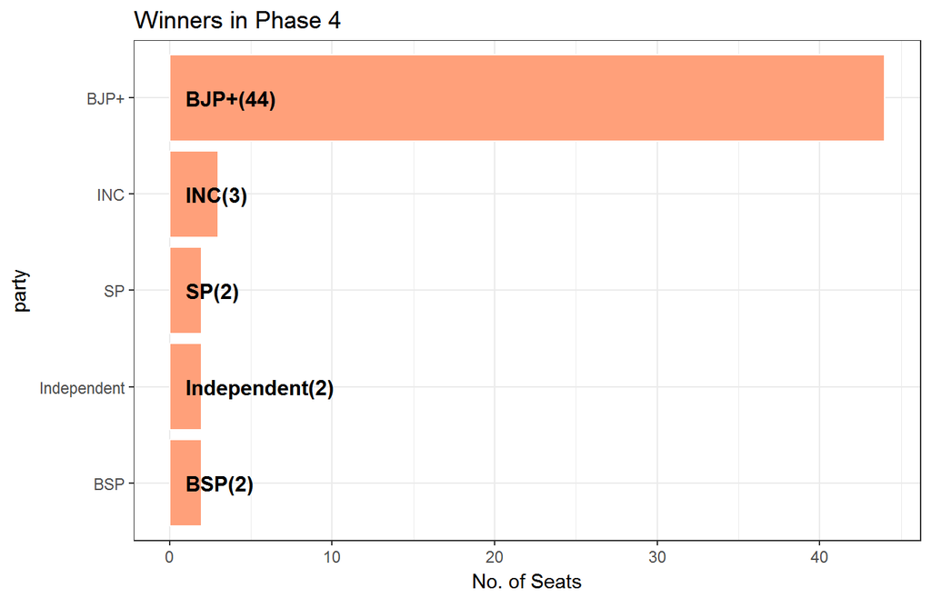

## 8.9 Phase 5 Districts

There are 11 Phase 5 districts.

|  | Phase 5 Districts |
| --- | --- |
| 1 | Ambedkar Nagar |
| 2 | Amethi |
| 3 | Bahraich |
| 4 | Balarampur |
| 5 | Basti |
| 6 | Faizabad |
| 7 | Gonda |
| 8 | Sant Kabir Nagar |
| 9 | Shravasti |
| 10 | Siddharthnagar |

[output cut: 1 more lines]

## 8.10 Phase 5 Winners

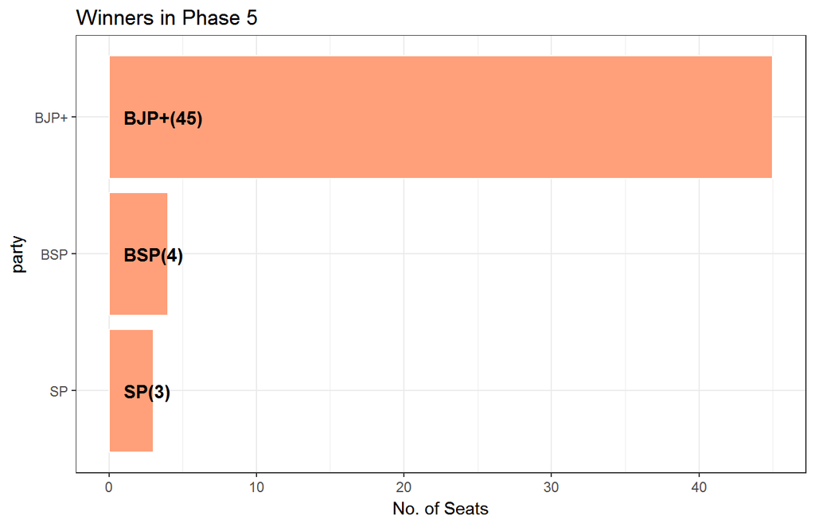

## 8.11 Phase 6 Districts

There are 7 Phase 6 districts.

|  | Phase 6 Districts |
| --- | --- |
| 1 | Azamgarh |
| 2 | Ballia |
| 3 | Deoria |
| 4 | Gorakhpur |
| 5 | Kushinagar |
| 6 | Maharajganj |
| 7 | Mau |

## 8.12 Phase 6 Winners

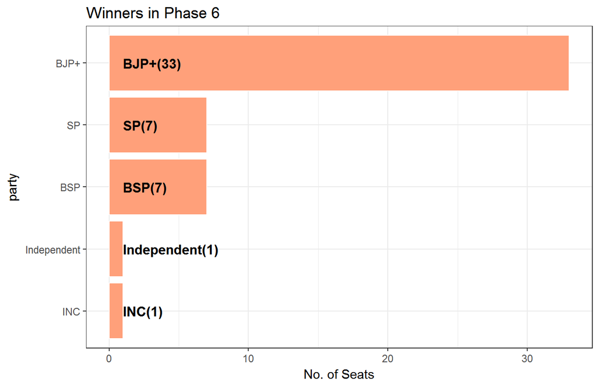

## 8.13 Phase 7 Districts

There are 7 Phase 7 districts.

[output not shown]

## 8.14 Phase 7 Winners

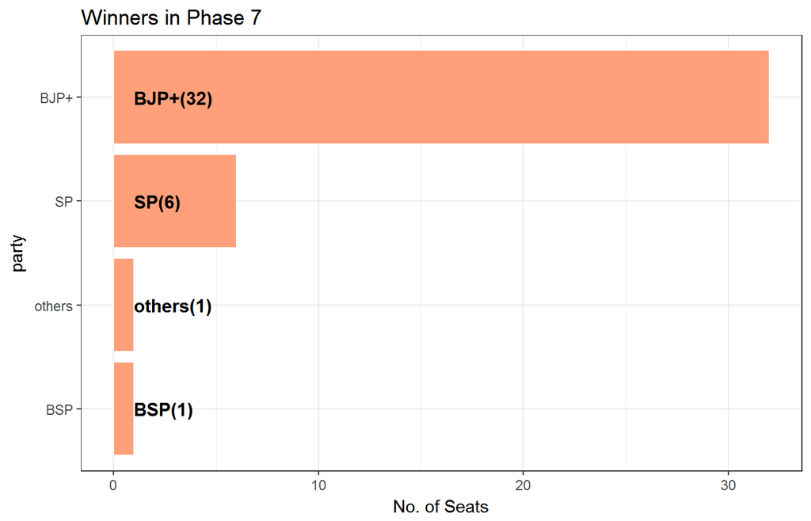

# 9 Winners and Surnames

The graph illustrates the most **common surnames** among the election winners.

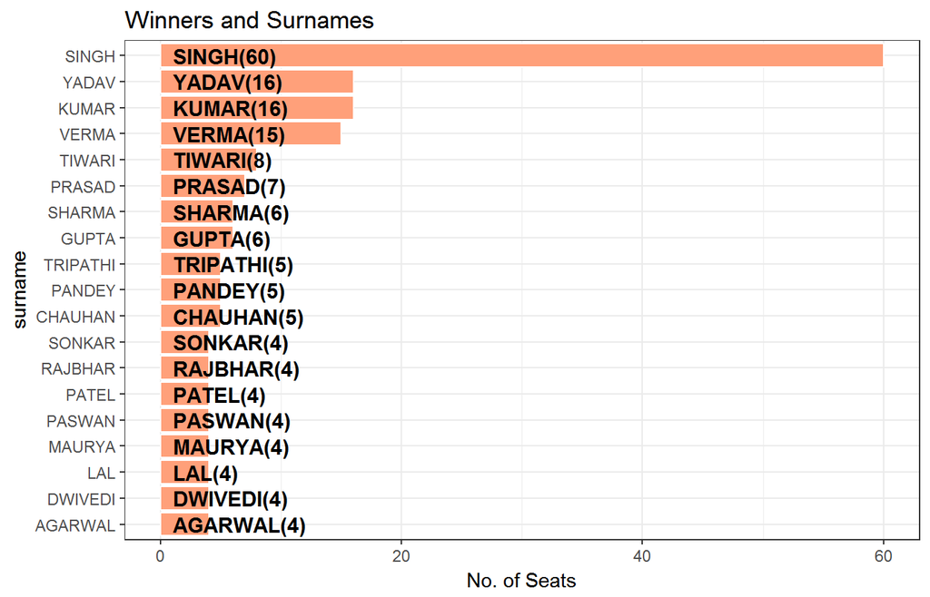